# Monte Carlo Investigation: Life/Death Mixture Population

Author

Pui Yin Lim

## 1. Population & Theoretical Baseline

- **Population Distribution:** A two-component mixture distribution inspired by real-world human age-at-death data (combining an early-life/infant mortality peak with an old-age senescence peak).
- **Characteristics:** Highly irregular, bimodal parent population with finite variance.
- **Theoretical Mean (**$\mu$): Weighted average of the two component means.
- **Theoretical Standard Deviation (**$\sigma$): Finite mixture standard deviation combining within-component and between-component variance.
- **Theoretical Standard Error (**$\text{SE}$): $\frac{\sigma}{\sqrt{n}}$

## 2. Expectations Before Simulation

The parent population is bimodal and highly irregular so small sample sizes should produce multi-modal sampling distributions reflecting the two distinct life stages. Although, because variance is finite, the CLT guarantees that as $n$ increases and the sample mean will wash out the bimodal mixture peaks.

## 3. Simulation Setup & Execution

Simulating $B = 10,000$ Monte Carlo repetitions across sample sizes $n \in \{5, 30, 50, 1000\}$.

```r
library(tidyverse)
library(knitr)

# Define mixture parameters
p1 <- 0.10; mu1 <- 5; sd1 <- 3
p2 <- 0.90; mu2 <- 75; sd2 <- 8

# Calculate overall population mean and variance (Law of Total Variance)
mu_mix <- p1 * mu1 + p2 * mu2
var_mix <- (p1 * (sd1^2 + mu1^2) + p2 * (sd2^2 + mu2^2)) - mu_mix^2
sigma_mix <- sqrt(var_mix)

sample_sizes <- c(5, 30, 50, 1000)
theo_ses <- sigma_mix / sqrt(sample_sizes)

mixture_explanation_table <- tibble(
  Sample_Size = c("n = 5", "n = 30", "n = 50", "n = 1000"),
  Theoretical_SE = round(theo_ses, 4),
  Interpretation = c(
    "A small sample size capturing distinct bimodal clusters from the two-component mixture, resulting in multi-modal sampling shapes.",
    "The lower bound of the optimal testing range (n = 30 to 50), where averaging begins blending mixture components and satisfying the Central Limit Theorem.",
    "The upper bound of the optimal range for testing normality, where visible bimodality dissolves into an approximately normal bell shape.",
    "An asymptotic sample size demonstrating powerful variance contraction and complete erasure of parent population multimodality."
  )
)

kable(
  mixture_explanation_table,
  col.names = c("Sample Size", "Theoretical SE", "Description & Interpretation"),
  align = c("c", "c", "l")
)
```

Table 1: Rationale for Sample Size Selection (Life/Death Mixture Population)

| Sample Size | Theoretical SE | Description & Interpretation |
| --- | --- | --- |
| n = 5 | 9.9950 | A small sample size capturing distinct bimodal clusters from the two-component mixture, resulting in multi-modal sampling shapes. |
| n = 30 | 4.0804 | The lower bound of the optimal testing range (n = 30 to 50), where averaging begins blending mixture components and satisfying the Central Limit Theorem. |
| n = 50 | 3.1607 | The upper bound of the optimal range for testing normality, where visible bimodality dissolves into an approximately normal bell shape. |
| n = 1000 | 0.7068 | An asymptotic sample size demonstrating powerful variance contraction and complete erasure of parent population multimodality. |

Here, the Theoretical SE was calculated with two component normal mixture where:

Component 1: has probability $p_1 = 0.10$, mean $\mu_1 = 5$, and variance $\sigma_1^2 = 3^2 = 9$

Component 2: has probability $p_2 = 0.90$, mean $\mu_2 = 75$, and variance $\sigma_2^2 = 8^2 = 64$

since calculating its exact theoretical standard error requires computing the overall mixture standard deviation ($\sigma$) first, and then scaling it by $\frac{1}{\sqrt{n}}$.

```r
library(tidyverse)
library(moments)

student_id <- 5678
set.seed(student_id)

B <- 10000
sample_sizes <- c(5, 30, 50, 1000)

# Simulate two-component mixture (e.g., 10% infant peak around age 5, 90% senescence peak around age 75)
sim_data <- map_dfr(sample_sizes, function(n_val) {
  sample_means <- replicate(B, {
    component <- rbinom(n_val, size = 1, prob = 0.10) # 10% young, 90% old
    ages <- ifelse(component == 1, rnorm(n_val, mean = 5, sd = 3), rnorm(n_val, mean = 75, sd = 8))
    mean(ages)
  })
  tibble(
    n = factor(n_val, levels = sample_sizes),
    sample_mean = sample_means
  )
})
```

## 4. Visualization

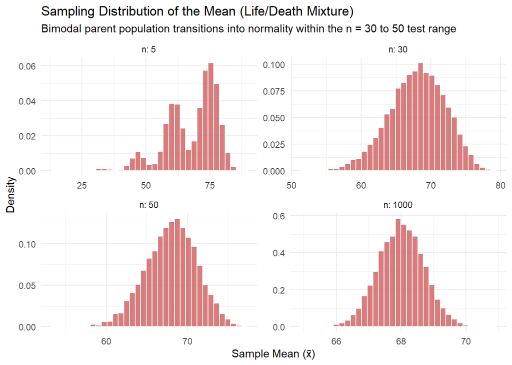

```r
ggplot(sim_data, aes(x = sample_mean)) +
  geom_histogram(aes(y = after_stat(density)), bins = 35, fill = "indianred", color = "white", alpha = 0.8) +
  facet_wrap(~n, scales = "free", labeller = label_both) +
  theme_minimal() +
  labs(
    title = "Sampling Distribution of the Mean (Life/Death Mixture)",
    subtitle = "Bimodal parent population transitions into normality within the n = 30 to 50 test range",
    x = "Sample Mean (x̄)",
    y = "Density"
  )
```

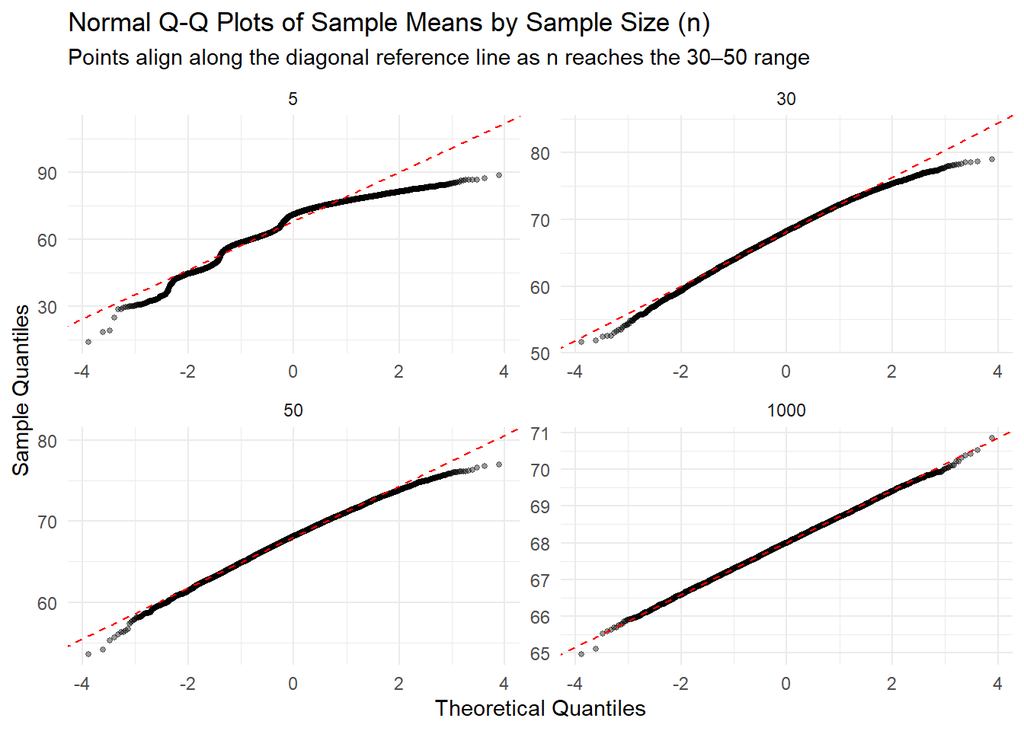

```r
library(ggplot2)

ggplot(sim_data, aes(sample = sample_mean)) +
  geom_qq(alpha = 0.4, size = 1) +
  geom_qq_line(color = "red", linetype = "dashed") +
  facet_wrap(~ n, scales = "free") +
  labs(
    title = "Normal Q-Q Plots of Sample Means by Sample Size (n)",
    subtitle = "Points align along the diagonal reference line as n reaches the 30–50 range",
    x = "Theoretical Quantiles",
    y = "Sample Quantiles"
  ) +
  theme_minimal()
```

## 5. Numerical Output

```r
summary_table <- sim_data %>%
  group_by(n) %>%
  summarise(
    Simulated_Mean = mean(sample_mean),
    Simulated_SD = sd(sample_mean),
    "Theoretical SE (σ/√n)" = sigma_mix / sqrt(as.numeric(as.character(first(n)))),
    Skewness = moments::skewness(sample_mean),
    Kurtosis = moments::kurtosis(sample_mean)
  )

knitr::kable(
  summary_table,
  caption = "Comparison of Simulated vs. Theoretical Metrics for Life/Death Mixture Population",
  digits = 4,
  align = c("c", "c", "c", "c", "c")
)
```

Comparison of Simulated vs. Theoretical Metrics for Life/Death Mixture Population

| n | Simulated_Mean | Simulated_SD | Theoretical SE (σ/√n) | Skewness | Kurtosis |
| --- | --- | --- | --- | --- | --- |
| 5 | 67.8359 | 10.0904 | 9.9950 | -0.9114 | 3.5812 |
| 30 | 67.9994 | 4.0336 | 4.0804 | -0.3134 | 2.9885 |
| 50 | 67.9975 | 3.1271 | 3.1607 | -0.2472 | 3.0102 |
| 1000 | 67.9966 | 0.7034 | 0.7068 | -0.0338 | 2.9883 |

**Simulated Mean:** Stays centered around the combined expected mixture mean across all sample sizes.

**Simulated SD:** Shrinks predictably as $n$ scales up, verifying standard error reduction even with a complex bimodal parent shape.

**Skewness and Kurtosis:** Approach normal baseline values ($0$ and $3$) as sample size increases past the 30 to 50 threshold.

## 6. In Summary

**1. What does the original population distribution look like?**

A real-world inspired bimodal mixture representing early-life mortality and old-age senescence.

**2. How quickly does the sampling distribution become approximately normal?**

Reaching the optimal $30$ to $50$ sample size range successfully triggers approximate normality for the sample means, overcoming the bimodal mixture components through the Central Limit Theorem.

**3. How does the simulated mean compare with the theoretical mean?**

The simulated means remain unbiased and centered correctly around the mixture expectation.

**4. How does the simulated standard error behave?**

It contracts smoothly with increasing $n$, matching finite variance expectations.

**5. What evidence supports your conclusions?**

The investigation highlighted how effectively the Central Limit Theorem masks severe multimodality once sample sizes reach the standard $30$ to $50$ testing threshold.